# Data_Generation - Solutions - Midterm Exam

Pouria

3/3/2022

```r
library(magrittr) # You can use %>% for nested functions in data manipulation
library(dplyr)    # For data manipulation
library(tidyr)    # For tidying your data (columns and rows)
library(ggplot2)  # For plotting
library(boot)     # For bootstrapping and cross-validation
library(nlme)     # For mixed-effect models


# Feel free to add your libraries of interest if needed
```

# Create the data points and visualize

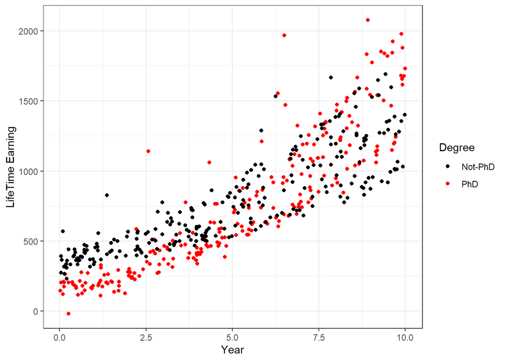

```r
set.seed(123)

n.groups = 10

Year1 <- Year2 <- Earning1 <- Earning2 <- matrix(rep(0,250),ncol = n.groups/2)
for (i in 1:(n.groups/2)){

  s1 <- sample(c(20,50,60,70),1)
  s2 <- sample(c(35,65,60,80),1)

  noise1 = rnorm(48, 0, s1)
  noise2 = rnorm(48, 0, s2)

  noise1 = c(noise1, rnorm(2, 400, 300))
  noise2 = c(noise2, rnorm(2, 400, 200))

  Year1[,i] <- runif(50, 0, 10)
  Year2[,i] <- runif(50, 0, 10)

  coef1.rand <- c(rnorm(1,10,50), rnorm(1,5,15), rnorm(1,0,2))
  coef2.rand <- c(rnorm(1,15,80), rnorm(1,5,20), rnorm(1,0,.8))


  Earning1[,i] <- 90+coef1.rand[1] + Year1[,i]*(25+coef1.rand[2]) + Year1[,i]^2*(10+coef1.rand[3]) + noise1


  Earning2[,i] <- 300+coef2.rand[1] + Year2[,i]*(60+coef2.rand[2]) + Year2[,i]^2*(4+coef2.rand[3]) + noise2
}


# names1 <- factor(c("P1", "P2", "P3", "P4", "P5", "P6", "P7", "P8", "P9", "P10"))
# names2 <- factor(c("N1", "N2", "N3", "N4", "N5", "N6", "N7", "N8", "N9", "N10"))

names1 <- factor(c("P1", "P2", "P3", "P4", "P5"))
names2 <- factor(c("N1", "N2", "N3", "N4", "N5"))





df.Year1 <- data.frame(Year1)
df.Year1.long <- df.Year1 %>%
  set_colnames(names1)%>%
  pivot_longer(1:5, names_to = "Group", values_to = "Year")

# names(df.Year1.long)

df.Earning1 <- data.frame(Earning1)
df.Earning1.long <- df.Earning1 %>%
  set_colnames(names1)%>%
  pivot_longer(1:5, names_to = "Group", values_to = "Earning")

df.Earning1.long$Group <- NULL

df1.long <- data.frame(df.Year1.long, df.Earning1.long)



df.Year2 <- data.frame(Year2)
df.Year2.long <- df.Year2 %>%
  set_colnames(names2)%>%
  pivot_longer(1:5, names_to = "Group", values_to = "Year")

# names(df.Year2.long)

df.Earning2 <- data.frame(Earning2)
df.Earning2.long <- df.Earning2 %>%
  set_colnames(names2)%>%
  pivot_longer(1:5, names_to = "Group", values_to = "Earning")

df.Earning2.long$Group <- NULL

df2.long <- data.frame(df.Year2.long, df.Earning2.long)


Degree <- rbind(matrix(c(rep("PhD", dim(df1.long)[1])), nrow = dim(df1.long)[1]) ,
                matrix(c(rep("Not-PhD", dim(df2.long)[1])), nrow = dim(df2.long)[1]))


Earnings.df <- data.frame(rbind(df1.long, df2.long) , Degree) %>%
  mutate(Group = factor(Group), Degree = factor(Degree))




attach(Earnings.df)


ggplot(Earnings.df) +
  geom_point(aes(x = Year, y = Earning, col = Degree)) +
  ylab("LifeTime Earning") +
  xlab("Year") +
  scale_color_manual(values = c("black", "red")) +
  theme_bw()
```

# Test the fits for the data

```r
lm.fit1 <- lm(Earning ~ Year*Degree, Earnings.df)
summary(lm.fit1)
```

```
##
## Call:
## lm(formula = Earning ~ Year * Degree, data = Earnings.df)
##
## Residuals:
##     Min      1Q  Median      3Q     Max
## -383.65 -153.04   -0.98  100.15  998.99
##
## Coefficients:
##                Estimate Std. Error t value Pr(>|t|)
## (Intercept)     286.746     23.792  12.052   <2e-16 ***
## Year             98.448      4.116  23.917   <2e-16 ***
## DegreePhD      -309.101     34.643  -8.922   <2e-16 ***
## Year:DegreePhD   54.021      5.938   9.098   <2e-16 ***
## ---
## Signif. codes:  0 '***' 0.001 '**' 0.01 '*' 0.05 '.' 0.1 ' ' 1
##
## Residual standard error: 195.9 on 496 degrees of freedom
## Multiple R-squared:  0.7879, Adjusted R-squared:  0.7866
## F-statistic:   614 on 3 and 496 DF,  p-value: < 2.2e-16
```

```r
lm.fit2 <- lm(Earning ~ Year*Degree + I(Year^2)*Degree, Earnings.df)
summary(lm.fit2)
```

```
##
## Call:
## lm(formula = Earning ~ Year * Degree + I(Year^2) * Degree, data = Earnings.df)
##
## Residuals:
##     Min      1Q  Median      3Q     Max
## -437.03 -108.38  -10.18   81.39 1063.65
##
## Coefficients:
##                     Estimate Std. Error t value Pr(>|t|)
## (Intercept)          339.086     31.967  10.607  < 2e-16 ***
## Year                  64.347     15.207   4.231 2.77e-05 ***
## DegreePhD           -187.809     47.229  -3.977 8.04e-05 ***
## I(Year^2)              3.470      1.495   2.321 0.020696 *
## Year:DegreePhD       -18.307     22.044  -0.830 0.406684
## DegreePhD:I(Year^2)    7.262      2.158   3.365 0.000824 ***
## ---
## Signif. codes:  0 '***' 0.001 '**' 0.01 '*' 0.05 '.' 0.1 ' ' 1
##
## Residual standard error: 186.6 on 494 degrees of freedom
## Multiple R-squared:  0.8084, Adjusted R-squared:  0.8065
## F-statistic: 416.8 on 5 and 494 DF,  p-value: < 2.2e-16
```

# Exam Questions

Description of the dataset:

This dataset includes the lifetime earnings (or cumulative earnings) (`Earning`) of a sample of age-matched individuals as a function of years of working (`Year`). The individuals either have PhD or they don’t noted in variable `Degree`, so the baseline year begins with when the PhD individuals have graduated; thus looking at data it makes sense that those with no PhD could start with higher number because they have already been in the job market while those with PhD were studying. The dataset have been sampled from 5 different groups (`Group`) within each `PhD` and `not-PhD` degrees. We aim to take a closer look into this dataset and interpret it using our knowledge of exploratory analysis and statistical learning/modeling that we have gained so far.

1. Implement a **simple linear regression** analysis (call the model `fit1`) to predict the lifetime earning (`Earning`) as the response variable with `Year`, `Degree` and their interactions as the predictors.

1A. **Summarize** the model and report your findings on what predictors have **significant effects** on variations in `Earning`. If there are more than one model, report all their **intercepts and slopes**.

1B. **Plot the fits**. Ensure to include the **data points** split into “PhD” and “not-PhD” degrees. Read these results and report your **inference** in general terms based on the variable names.

1C. Plot the **diagnostics**. Check all the linear model **assumptions** and make comments.

1D. Use both SE equation (provided below or Eq. 8 in the book) and bootstrapping (200 times) methods to calculate the standard error on the coefficient corresponding to the variable `Year` and compare them. Which one is a more accurate estimate of standard error and why?

$$SE(\hat \beta_{Year})^2=\frac{\sigma^2}{\sum_{i=1}^n(x_i-\bar{x})^2}$$

2. Now fit a new linear model (call it `fit2`) by adding a square term on `Year` and its interaction with `Degree` to the relationship of your model `fit1` to predict `Earning` again.

2A. **Summarize** the model and report your findings on **significant effects**. If there are more than one model, report all their **intercepts and slopes**.

2B. **Plot the fits**. Ensure to include the **data points** split into “PhD” and “not-PhD” degrees. Read these results and report your **inference** in general terms based on the variable names.

2C. Use `ANOVA` to compare the model with quadratic term and the simple model in Problem 1. Comment on significance of the difference.

2D. Now, of these the two models determine which one is better using a 10-fold cross-validation.

3. In this problem, we aim to fit a linear mixed effect model to the data to predict `Earning` by other continuous and categorical variables in the dataset.

3B. **Fit a linear mixed effect model** with a baseline similar to `fit1` (`Year`, `Degree` and interactions) and a random effect of `Group`.

- Perform this with both a general and a diagonal covariance matrix structure and save the best fit to `lm.fit.mixed`. (show your work on how you chose the better mixed-effect fit)

3C. **Fixed, random, and mixed effects**; Tease out the fixed-effect coefficients and the random-effect coefficients (for different groups); Only keep the significant ones.

3D. Plot the fixed-effect fits and mixed-effect fits per group on one graph.

3E. Plot the residuals of your mixed-effect model and compare it to 3A. How do you explain any similarity or difference between them?

4. **Bonus:** Take a linear regression of the entire data for one linear fit in predicting `Earning` by `Year` (no `Degree` and no `Group` effects).
- Take the intercept and slope coefficients obtained from this fit and then systematically evaluate the residual sum of squares (RSS, Eq. 3.3) around this optimal set of coefficients(range in `-/+ 10,000%` of the coefficients from the `lm()` with step size of `100` in your for-loop) to systematically create a contour plot of `RSS` against pairs of $\beta_0$ and $\beta_1$ similar to Fig. 3.2 in the book.
- Repeat above this time for `Year` centered about its mean value (You should first do a new fit and find its intercept and slopes with `lm()`)
- Compare the shapes of contour plots in these two centered and un-centered cases. What is the phenomenon you observe? Comment on your results.

# Problem 1

1. Implement a simple linear regression analysis (call the model `fit1`) to predict the lifetime earning (`Earning`) as the response variable with `Year`, `Degree` and their interactions as the predictors.

## 1A. Regression for `Earning` as a function of `Year`, `Degree` and their interactions.

**Provide a summary of your model and make comments on the significant effects and the meaning of each of them, i.e., what values do the slopes and the intercepts take on?**

```r
lm.fit1 <- lm(Earning ~ Year*Degree, Earnings.df)
summary(lm.fit1)
```

```
##
## Call:
## lm(formula = Earning ~ Year * Degree, data = Earnings.df)
##
## Residuals:
##     Min      1Q  Median      3Q     Max
## -383.65 -153.04   -0.98  100.15  998.99
##
## Coefficients:
##                Estimate Std. Error t value Pr(>|t|)
## (Intercept)     286.746     23.792  12.052   <2e-16 ***
## Year             98.448      4.116  23.917   <2e-16 ***
## DegreePhD      -309.101     34.643  -8.922   <2e-16 ***
## Year:DegreePhD   54.021      5.938   9.098   <2e-16 ***
## ---
## Signif. codes:  0 '***' 0.001 '**' 0.01 '*' 0.05 '.' 0.1 ' ' 1
##
## Residual standard error: 195.9 on 496 degrees of freedom
## Multiple R-squared:  0.7879, Adjusted R-squared:  0.7866
## F-statistic:   614 on 3 and 496 DF,  p-value: < 2.2e-16
```

## 1B. Plot the fits

- **Make sure to also include the data points split into “PhD” and “notPhD” degrees.**
- **Make comments on how you read the data and the fit; What is your interpretation of these results?!**

```r
coeffs <- coef(lm.fit1)
coeffs
```

```
##    (Intercept)           Year      DegreePhD Year:DegreePhD
##      286.74596       98.44815     -309.10108       54.02078
```

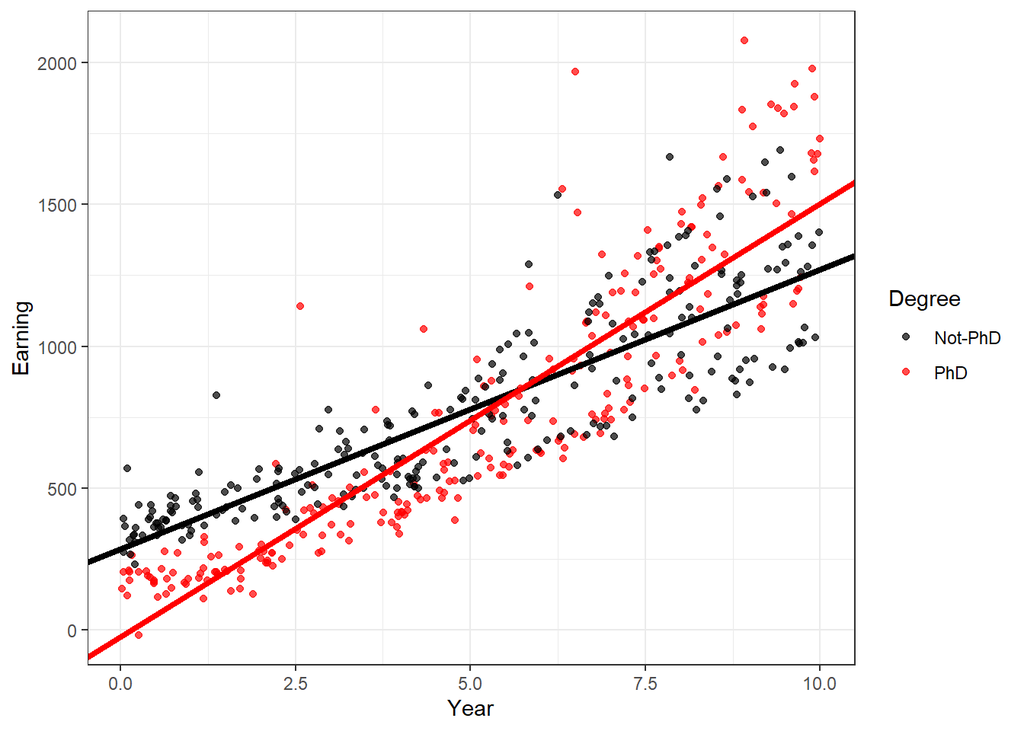

```r
ggplot(Earnings.df, aes(x=Year, y=Earning, col=Degree)) +
  geom_point(alpha=.7) +
  geom_abline(slope = coeffs[2], intercept = coeffs[1], col = "black", size = 1.5) +
  geom_abline(slope = coeffs[2]+coeffs[4], intercept = coeffs[1]+coeffs[3], col = "red" , size = 1.5) +
  scale_color_manual(values = c("black", "red")) +
  theme_bw()
```

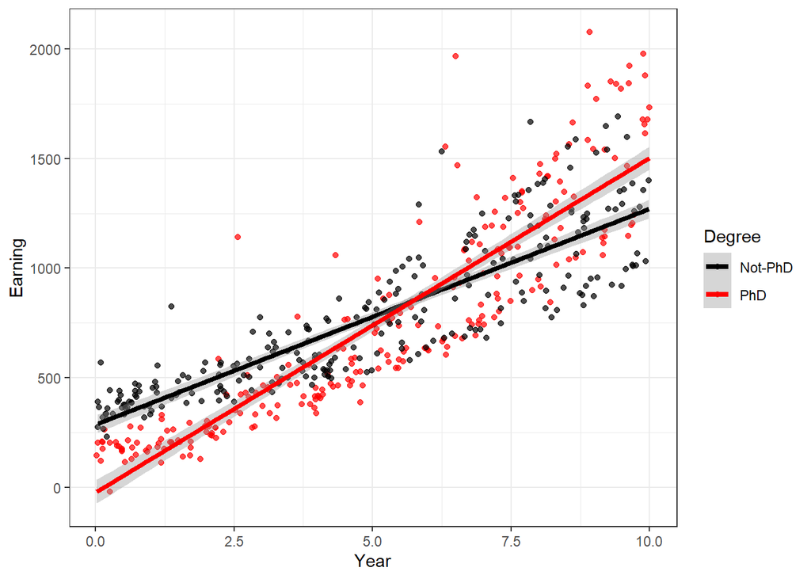

```r
ggplot(Earnings.df, aes(x=Year, y=Earning, col=Degree)) +
  geom_point(alpha=.7) +
  geom_smooth(method = "lm", formula = y~x, size = 1.5) +
  scale_color_manual(values = c("black", "red")) +
  theme_bw()
```

## 1C. Diagnostics Plot

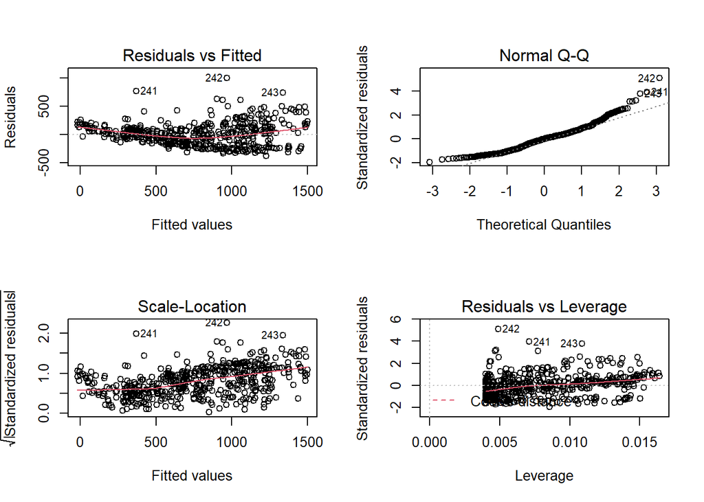

```r
par(mfrow=c(2,2))
plot(lm.fit1)
```

## 1D. Calculate SE using two methods

- Equation 3.8
  $$SE(\hat \beta_{Year})=\frac{\sigma}{\sqrt{\sum_{i=1}^n(x_i-\bar{x})^2}}$$

```r
Earnings.df_notPhD <- Earnings.df %>%
  filter(Degree == "Not-PhD")

sigma <- sqrt( sum(lm.fit1$residuals^2)/(500-2) )

SE.eq <- sigma / sqrt(sum( (Earnings.df_notPhD$Year - mean(Earnings.df_notPhD$Year) )^2 ))


# SE.eq <- sigma/
#   sqrt(sum( (Earnings.df$Year - mean(Earnings.df$Year) )^2 ))


SE.eq
```

```
## [1] 4.107899
```

- Bootstrapping 200 times

```r
boot.fn <- function (data , index){
  coef (lm(Earning ~ Year*Degree , data = data , subset = index))[2]
}

beta1.boot <- boot(Earnings.df , boot.fn, 200)

sd(beta1.boot$t)
```

```
## [1] 3.795884
```

# Problem 2

Now fit a new linear model (call it `fit2`) by adding a square term on `Year` and its interaction with `Degree` to the relationship of your model `fit1` to predict `Earning` again.

## 2A. **Fit and Summarize** the model and report your findings on **significant effects**. If there are more than one model, report all their **intercepts and slopes**.

```r
lm.fit2 <- lm(Earning ~ Year*Degree + I(Year^2)*Degree, Earnings.df)
summary(lm.fit2)
```

```
##
## Call:
## lm(formula = Earning ~ Year * Degree + I(Year^2) * Degree, data = Earnings.df)
##
## Residuals:
##     Min      1Q  Median      3Q     Max
## -437.03 -108.38  -10.18   81.39 1063.65
##
## Coefficients:
##                     Estimate Std. Error t value Pr(>|t|)
## (Intercept)          339.086     31.967  10.607  < 2e-16 ***
## Year                  64.347     15.207   4.231 2.77e-05 ***
## DegreePhD           -187.809     47.229  -3.977 8.04e-05 ***
## I(Year^2)              3.470      1.495   2.321 0.020696 *
## Year:DegreePhD       -18.307     22.044  -0.830 0.406684
## DegreePhD:I(Year^2)    7.262      2.158   3.365 0.000824 ***
## ---
## Signif. codes:  0 '***' 0.001 '**' 0.01 '*' 0.05 '.' 0.1 ' ' 1
##
## Residual standard error: 186.6 on 494 degrees of freedom
## Multiple R-squared:  0.8084, Adjusted R-squared:  0.8065
## F-statistic: 416.8 on 5 and 494 DF,  p-value: < 2.2e-16
```

2B. **Plot the fits**. Ensure to include the **data points** split into “PhD” and “notPhD” degrees. Read these results and report your **inference** in general terms based on the variable names.

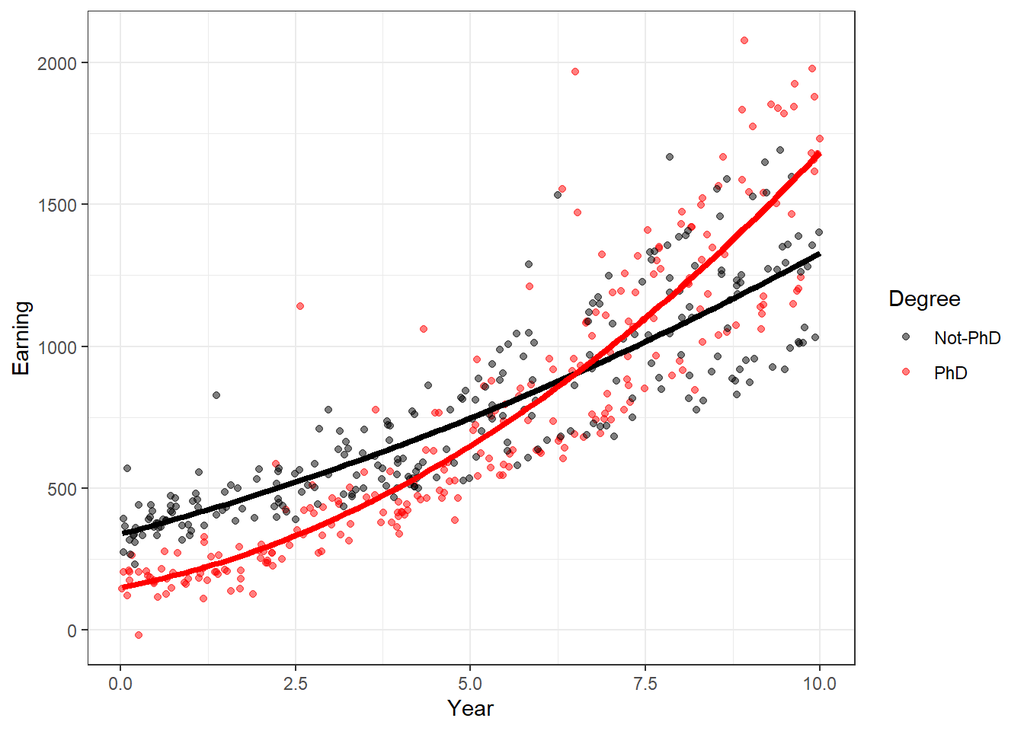

```r
# First: Use the coefficients and stat_function
coeff.fit2 <- coef(lm.fit2)

f1 <- function(x) coeff.fit2[1] + coeff.fit2[2]*x + coeff.fit2[4]*x^2
f2 <- function(x) coeff.fit2[1]+coeff.fit2[3] + (coeff.fit2[2]+coeff.fit2[5])*x + (coeff.fit2[4]+coeff.fit2[6])*x^2

ggplot(Earnings.df, aes(x=Year, y=Earning, col=Degree)) +
  geom_point(alpha=.5) +
  stat_function(fun=f1, colour="black", size=1.5) +
  stat_function(fun=f2, colour="red", size=1.5) +
  scale_color_manual(values = c("black", "red")) +
  theme_bw()
```

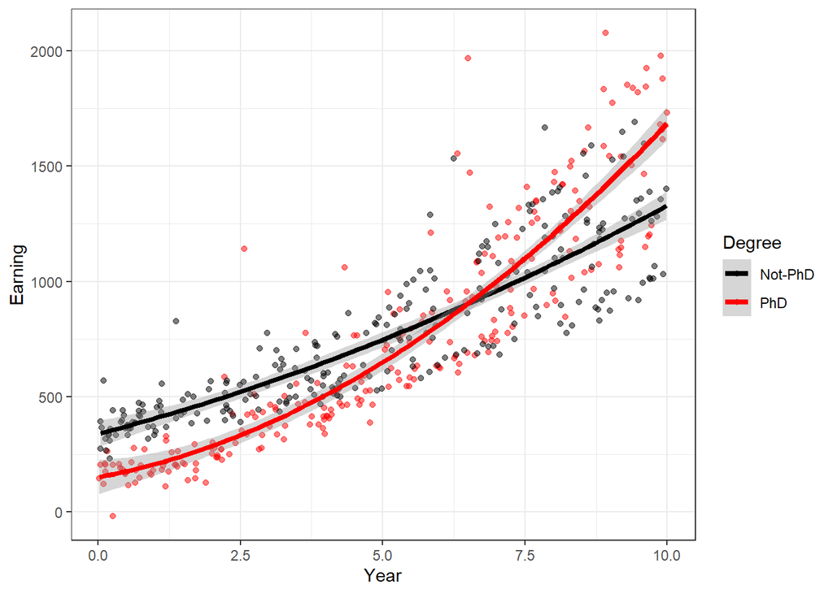

```r
# or: use geom_smooth with x+I(x^2)
# geom_smooth considers interactions by default
ggplot(Earnings.df, aes(x=Year, y=Earning, col=Degree)) +
  geom_point(alpha=.5) +
  geom_smooth(method="lm", formula = y~x+I(x^2), size=1.5) +
  scale_color_manual(values = c("black", "red")) +
  theme_bw()
```

## 2C. Compare the two fits using ANOVA

2C. Use `ANOVA` to compare the model with nonlinear term and the simple model in Problem 1. Comment on significance of the difference.

```r
# lm.fit3 <- lm(Earning ~ Year * Degree + I(Year^2):Degree)

anova(lm.fit2, lm.fit1)
```

```
## Analysis of Variance Table
##
## Model 1: Earning ~ Year * Degree + I(Year^2) * Degree
## Model 2: Earning ~ Year * Degree
##   Res.Df      RSS Df Sum of Sq     F    Pr(>F)
## 1    494 17192387
## 2    496 19035560 -2  -1843173 26.48 1.189e-11 ***
## ---
## Signif. codes:  0 '***' 0.001 '**' 0.01 '*' 0.05 '.' 0.1 ' ' 1
```

## Model selection using cross-validation

2D. Now, of these the two models determine which one is better using a 10-fold cross-validation.

```r
glm.fit1 <- glm (Earning ~ Year*Degree, data = Earnings.df)
glm.fit2 <- glm (Earning ~ Year*Degree + I(Year^2)*Degree, data = Earnings.df)

cv.error.fit1 <- cv.glm (Earnings.df , glm.fit1 , K = 10)$delta[1]
cv.error.fit2 <- cv.glm (Earnings.df , glm.fit2 , K = 10)$delta[1]

data.frame( cv.error.fit1, cv.error.fit2 )
```

```
##   cv.error.fit1 cv.error.fit2
## 1      38726.19      34921.57
```

# Problem 3

## 3A. Plot the residuals of `fit1` in a box-plot against `Group`.

```r
attach(Earnings.df)
```

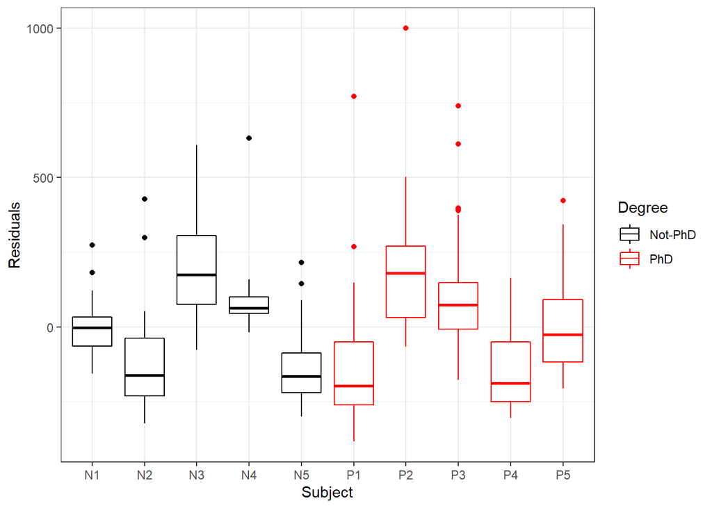

```r
ggplot(lm.fit1) +
  geom_boxplot(aes(x = Group, y = .resid, col = Degree)) +
  scale_color_manual(values=c("black", "red")) +
  xlab("Subject") + ylab("Residuals") +
  theme_bw()
```

## 3B. Fit linear mixed effect model

Fit a linear mixed effect model with a baseline similar to `fit1` (`Year`, `Degree` and interactions) and a random effect of `Group`.

```r
lm.fit.mixed <- lme(Earning ~ Year*Degree, data = Earnings.df, random=list( Group = pdDiag( ~Year) ) )

lm.fit.mixed <- lme(Earning ~ Year*Degree, data = Earnings.df, random= ~Year | Group)

summary(lm.fit.mixed)
```

```
## Linear mixed-effects model fit by REML
##   Data: Earnings.df
##        AIC      BIC    logLik
##   6280.226 6313.878 -3132.113
##
## Random effects:
##  Formula: ~Year | Group
##  Structure: General positive-definite, Log-Cholesky parametrization
##             StdDev    Corr
## (Intercept)  23.79864 (Intr)
## Year         31.30118 -0.681
## Residual    125.30395
##
## Fixed effects:  Earning ~ Year * Degree
##                     Value Std.Error  DF    t-value p-value
## (Intercept)     294.55444  18.62238 488  15.817228  0.0000
## Year             96.26521  14.24711 488   6.756826  0.0000
## DegreePhD      -297.56616  26.88746   8 -11.067096  0.0000
## Year:DegreePhD   51.68605  20.16508 488   2.563146  0.0107
##  Correlation:
##                (Intr) Year   DgrPhD
## Year           -0.513
## DegreePhD      -0.693  0.355
## Year:DegreePhD  0.362 -0.707 -0.510
##
## Standardized Within-Group Residuals:
##        Min         Q1        Med         Q3        Max
## -2.2877699 -0.5519305 -0.1256490  0.3244027  6.6040422
##
## Number of Observations: 500
## Number of Groups: 10
```

## 3C. Fixed, random, and mixed effects

1. Tease out the fixed-effect coefficients and the random-effect coefficients (for different groups); Only keep the significant ones.

```r
fixed.effects(lm.fit.mixed)
```

```
##    (Intercept)           Year      DegreePhD Year:DegreePhD
##      294.55444       96.26521     -297.56616       51.68605
```

```r
random.effects(lm.fit.mixed)
```

```
##    (Intercept)         Year
## N1   -1.164750   0.09668323
## N2    9.477761 -23.83643399
## N3  -23.196943  40.68877812
## N4    8.120356  12.85926332
## N5    6.763577 -29.80829067
## P1   27.777557 -35.68926964
## P2  -14.751571  38.77977945
## P3  -13.646295  23.98181465
## P4   14.476239 -32.37201082
## P5  -13.855930   5.29968636
```

2. Also, extract the mixed-effect coefficients for each group.

```r
coeff.mixed <- coef(lm.fit.mixed)
coeff.mixed
```

```
##    (Intercept)      Year DegreePhD Year:DegreePhD
## N1    293.3897  96.36190 -297.5662       51.68605
## N2    304.0322  72.42878 -297.5662       51.68605
## N3    271.3575 136.95399 -297.5662       51.68605
## N4    302.6748 109.12448 -297.5662       51.68605
## N5    301.3180  66.45692 -297.5662       51.68605
## P1    322.3320  60.57594 -297.5662       51.68605
## P2    279.8029 135.04499 -297.5662       51.68605
## P3    280.9081 120.24703 -297.5662       51.68605
## P4    309.0307  63.89320 -297.5662       51.68605
## P5    280.6985 101.56490 -297.5662       51.68605
```

## 3D. Plot the fixed effect fits and mixed effect fits for all groups.

Are there any groups for which the fixed effect would explain the trend in the data?

First obtain a 2-column structure for coefficients of fixed and mixed models for plotting in `geom_abline()`.

```r
coeffs.ranef <- random.effects(lm.fit.mixed)
coeffs.fixed <- fixed.effects(lm.fit.mixed)

coeffs.model.mixed <- matrix(rep(0,20), nrow = 10)
coeffs.model.fixed <- matrix(rep(0,20), nrow = 10)


coeffs.model.fixed[1:5,1] <- coeffs.fixed[1]
coeffs.model.fixed[1:5,2] <- coeffs.fixed[2]
coeffs.model.fixed[6:10,1]<- coeffs.fixed[1]+ coeffs.fixed[3]
coeffs.model.fixed[6:10,2]<- coeffs.fixed[2]+ coeffs.fixed[4]

coeffs.model.mixed[1:5,1] <- coeffs.ranef[1:5,1] + coeffs.fixed[1]
coeffs.model.mixed[1:5,2] <- coeffs.ranef[1:5,2] + coeffs.fixed[2]
coeffs.model.mixed[6:10,1]<- coeffs.ranef[6:10,1] + coeffs.fixed[1]+ coeffs.fixed[3]
coeffs.model.mixed[6:10,2]<- coeffs.ranef[6:10,2] + coeffs.fixed[2]+ coeffs.fixed[4]


ids <- Earnings.df %>% pull(Group) %>% levels() %>% factor()

# make a tibble with the data extracted above
coeffs.model.fixed <- tibble(Group = ids,
                  intercept = coeffs.model.fixed[,1],
                  slope = coeffs.model.fixed[,2])

coeffs.model.mixed <- tibble(Group = ids,
                  intercept = coeffs.model.mixed[,1],
                  slope = coeffs.model.mixed[,2])
```

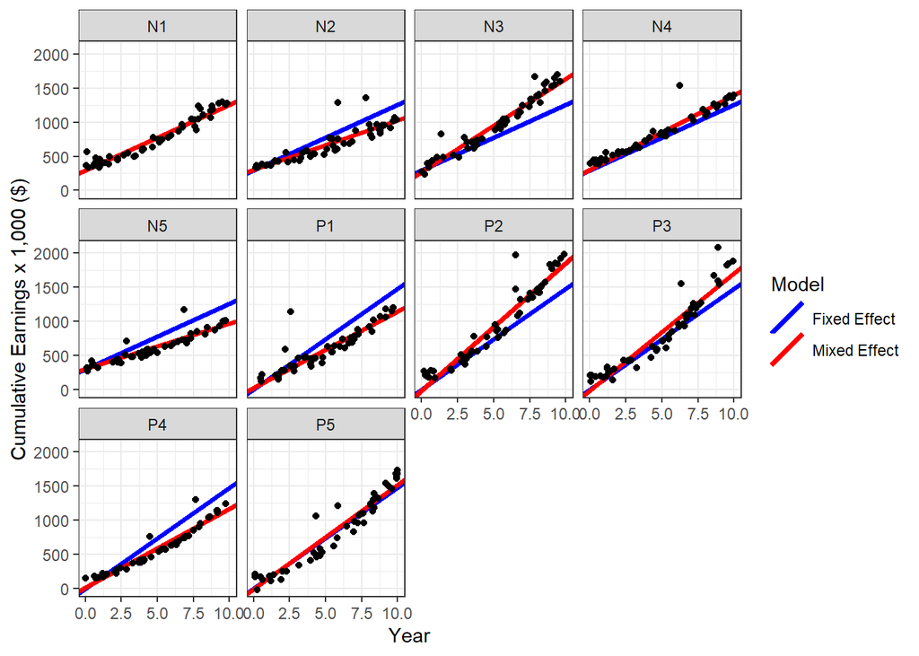

```r
ggplot(Earnings.df, aes(x = Year, y = Earning)) +
  geom_abline(data = coeffs.model.fixed, aes(intercept = intercept,
                  slope = slope, col="Fixed Effect"), size = 1.3) +
  geom_abline(data = coeffs.model.mixed, aes(intercept = intercept,
                  slope = slope, col="Mixed Effect"), size = 1.3) +
  geom_point() +
  facet_wrap(~Group) +
  labs(x = "Year", y = "Cumulative Earnings x 1,000 ($)", color = "Model") +
  scale_color_manual(values = c("blue", "red")) +
  theme_bw()
```

## 3.E Plot the residuals of the mixed-effect model (similar to 3A).

Is it different from 3A? Why or why not?

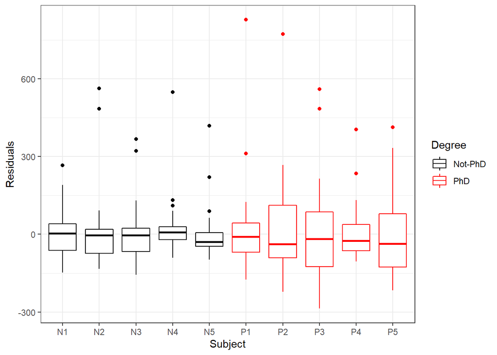

```r
Data_mixedeffect <- Earnings.df %>%
  mutate(fit = fitted(lm.fit.mixed),
         resid = residuals(lm.fit.mixed))

ggplot(Data_mixedeffect) +
  geom_boxplot(aes(x = Group, y = resid, col = Degree)) +
  scale_color_manual(values=c("black", "red")) +
  xlab("Subject") + ylab("Residuals") +
  theme_bw()
```

No Centering

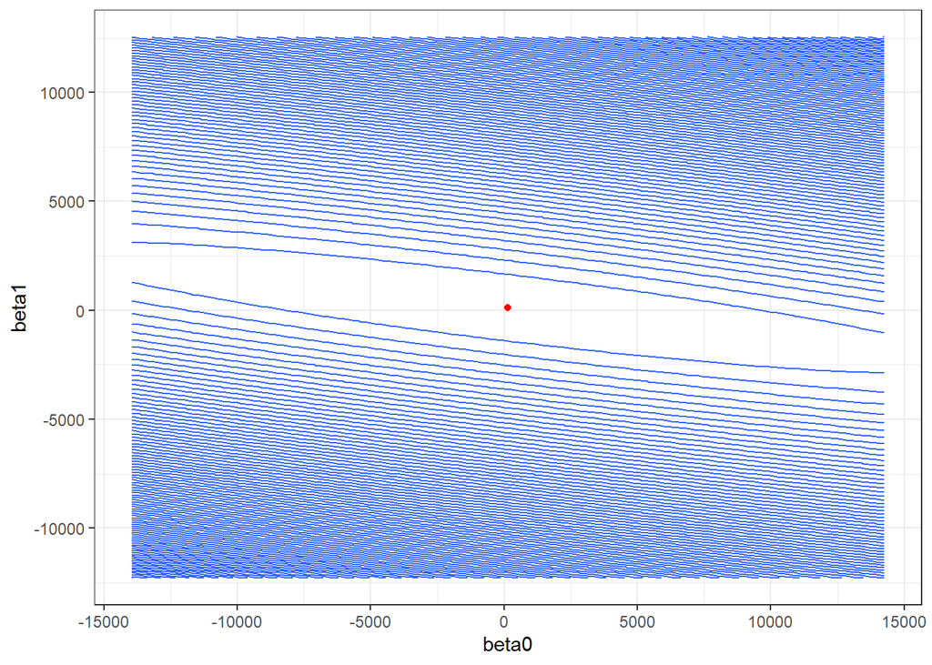

```r
Coefficients.noCentering <- coef(lm(Earning~Year))

beta0.lower <- Coefficients.noCentering[[1]] - 100*Coefficients.noCentering[[1]]
beta0.upper <- Coefficients.noCentering[[1]] + 100*Coefficients.noCentering[[1]]
beta1.lower <- Coefficients.noCentering[[2]] - 100*Coefficients.noCentering[[2]]
beta1.upper <- Coefficients.noCentering[[2]] + 100*Coefficients.noCentering[[2]]


beta0 <- beta1 <- 0
RSS <- 0
i<-0

for (b0 in seq(beta0.lower, beta0.upper, length.out=100)){
  for(b1 in seq(beta1.lower, beta1.upper, length.out=100)){
    i <- i+1
    beta0[i] <- b0
    beta1[i] <- b1

    Earning.hat <- b0 + b1*Year
    RSS[i] <- sum((Earning - Earning.hat)^2)
  }
}

RSS.df.noCentering <- tibble(beta0, beta1, RSS)

ggplot(RSS.df.noCentering, aes(x=beta0, y=beta1, z=RSS)) +
  geom_contour(bins=100) +
  geom_point(aes(x=Coefficients.noCentering[[1]], y=Coefficients.noCentering[[2]]), col="red") +
  theme_bw()
```

With Centering

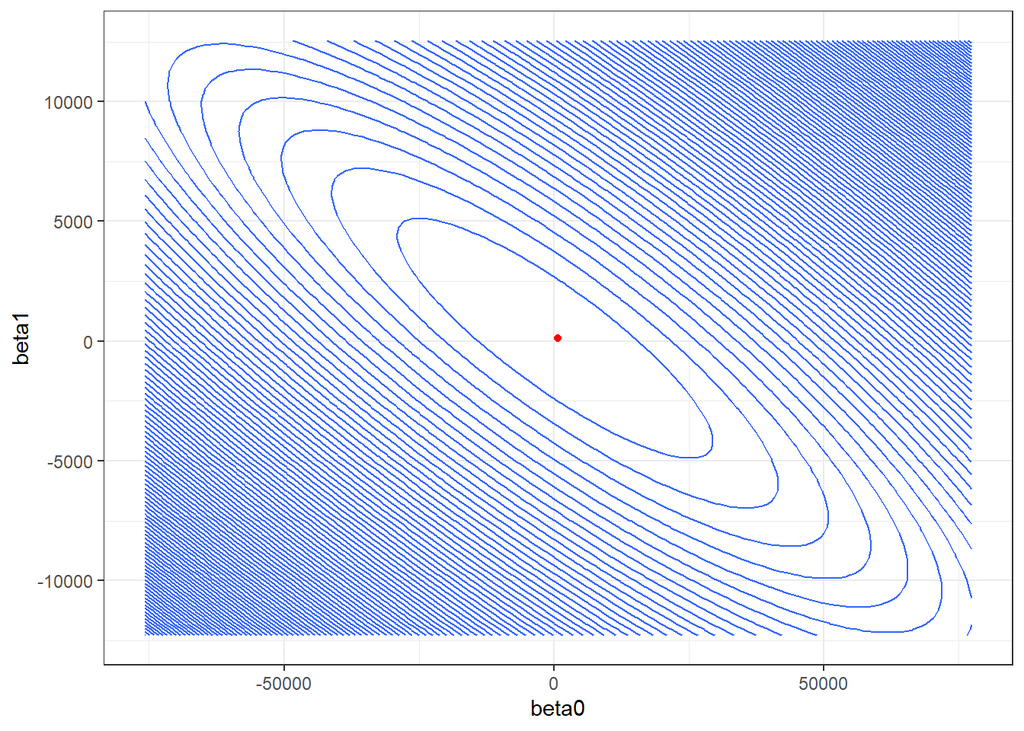

```r
Coefficients.Centering <- coef(lm(Earning~I(Year-mean(Year))))

beta0.lower <- Coefficients.Centering[[1]] - 100*Coefficients.Centering[[1]]
beta0.upper <- Coefficients.Centering[[1]] + 100*Coefficients.Centering[[1]]
beta1.lower <- Coefficients.Centering[[2]] - 100*Coefficients.Centering[[2]]
beta1.upper <- Coefficients.Centering[[2]] + 100*Coefficients.Centering[[2]]


beta0 <- beta1 <- 0
RSS <- 0
i<-0

for (b0 in seq(beta0.lower, beta0.upper, length.out=100)){
  for(b1 in seq(beta1.lower, beta1.upper, length.out=100)){
    i <- i+1
    beta0[i] <- b0
    beta1[i] <- b1

    Earning.hat <- b0 + b1*Year
    RSS[i] <- sum((Earning - Earning.hat)^2)
  }
}

RSS.df.Centering <- tibble(beta0, beta1, RSS)

ggplot(RSS.df.Centering, aes(x=beta0, y=beta1, z=RSS)) +
  geom_contour(bins=100) +
  geom_point(aes(x=Coefficients.Centering[[1]], y=Coefficients.Centering[[2]]), col="red") +
  theme_bw()
```